# Power Analysis - Battery Choices

# Step 3: Generate Designs

## Different designs

### Random Method

- **random**: randomly samples profiles for each respondent independently; maximum diversity but may be less statistically efficient

```r
design_random_fixed_parameter <- cbc_design(
  profiles = profiles,
  priors = priors_fixed,
  method = "random", # randomized full-factorial design
  n_resp   = 3000, # Number of respondents
  n_alts   = 3,    # Number of alternatives per question
  n_q      = 6,    # Number of questions per respondent #6
  remove_dominant = TRUE
)

design_random_random_parameter <- cbc_design(
  profiles = profiles,
  priors = priors_random_parameter,
  method = "random", # randomized full-factorial design
  n_resp   = 3000, # Number of respondents
  n_alts   = 3,    # Number of alternatives per question
  n_q      = 6,    # Number of questions per respondent #6
  remove_dominant = TRUE
)
```

### Frequency-Based Methods

- **shortcut**: balances attribute level frequencies while avoiding duplicate profiles within questions.
- **minoverlap**: prioritizes minimizing attribute overlap within choice questions.
- **balanced**: optimizes both frequency balance and pairwise attribute interactions.

```r
design_shortcut <- cbc_design(
  profiles = profiles,
  method = "shortcut",
  n_resp   = 3000, # Number of respondents
  n_alts   = 3,    # Number of alternatives per question
  n_q      = 6    # Number of questions per respondent #6

)
```

```
Generating shortcut design for 3000 respondents using 13 cores...
```

```r
design_shortcut_fixed_parameter <- cbc_design(
  profiles = profiles,
  priors = priors_fixed,
  method = "shortcut",
  n_resp   = 3000, # Number of respondents
  n_alts   = 3,    # Number of alternatives per question
  n_q      = 6   # Number of questions per respondent #6
)
```

```
Generating shortcut design for 3000 respondents using 13 cores...
```

```r
## Code will not run
# design_shortcut_fixed_parameter_remove_dominant <- cbc_design(
#   profiles = profiles,
#   priors = priors_fixed,
#   method = "shortcut",
#   n_resp   = 3000, # Number of respondents
#   n_alts   = 3,    # Number of alternatives per question
#   n_q      = 6,   # Number of questions per respondent #6
#   remove_dominant = TRUE
# )
```

## Design comparisons

```r
cbc_compare(
  "Random_fixed_parameter" = design_random_fixed_parameter,
  "Random_random_parameter" = design_random_random_parameter,
  "Shortcut" = design_shortcut,
  "Shortcut_fixed_parameter" = design_shortcut_fixed_parameter
)
```

```
CBC Design Comparison
=====================
Designs compared: 4
Metrics: structure, efficiency, balance, overlap
Sorted by: d_error (ascending)

Structure
=====================
                   Design   Method respondents questions
   Random_fixed_parameter   random        3000         6
  Random_random_parameter   random        3000         6
                 Shortcut shortcut        3000         6
 Shortcut_fixed_parameter shortcut        3000         6
 Alternatives Blocks    Profile Usage
            3      1 (2399/2400) 100%
            3      1 (2399/2400) 100%
            3      1 (2400/2400) 100%
            3      1 (2400/2400) 100%
 No Choice Labeled?
        No       No
        No       No
        No       No
        No       No

Design Metrics
=====================
                   Design   Method D-Error (Null) D-Error (Prior) Balance
   Random_fixed_parameter   random             NA              NA   0.866
  Random_random_parameter   random             NA              NA   0.864
                 Shortcut shortcut             NA              NA   0.892
 Shortcut_fixed_parameter shortcut             NA              NA   0.892
 Overlap
   0.144
   0.144
   0.000
   0.000

Interpretation:
- D-Error: Lower is better (design efficiency)
- Balance: Higher is better (level distribution)
- Overlap: Lower is better (attribute variation)
- Profile Usage: Higher means more profiles used

Best performers:
- Balance: Shortcut (0.892)
- Overlap: Shortcut (0.000)
- Profile Usage: Random_fixed_parameter (100.0%)

Use summary() for detailed information on any one design.
```

# Step 4: Inspect Design

**Goal: Evaluate the quality and properties of the design.** - D-error: Lower values indicate more efficient designs - Balance: Higher scores indicate better attribute level balance - Overlap: Lower scores indicate less attribute overlap within questions - Profile usage: Higher percentages indicate better use of available profiles

```r
cbc_inspect(design_random_fixed_parameter)
```

```
DESIGN SUMMARY
=========================

STRUCTURE
================
Method: random
Created: 2025-07-15 13:27:06
Respondents: 3000
Questions per respondent: 6
Alternatives per question: 3
Total choice sets: 18000
Profile usage: 2399/2400 (100.0%)
Special features:
  • Dominance removal: total, partial

SUMMARY METRICS
=================
D-error calculation not available for random designs
Overall balance score: 0.866 (higher is better)
Overall overlap score: 0.144 (lower is better)

VARIABLE ENCODING
=================
Format: Dummy-coded (battery_refurbish)
💡 Use cbc_decode_design() to convert to categorical format

ATTRIBUTE BALANCE
=================
Overall balance score: 0.866 (higher is better)

Individual attribute level counts:

veh_mileage:

 1.5    2  2.5    3  3.5    4  4.5    5
6733 6622 6641 6716 6797 6836 6861 6794
  Balance score: 0.987 (higher is better)

veh_price:

```

[output cut: 69 more lines]

```
  Questions by # unique levels:
  1 (complete overlap):   3.7%  (674 / 18000 questions)
  2 (partial overlap):   47.8%  (8603 / 18000 questions)
  3 (partial overlap):   48.5%  (8723 / 18000 questions)
  4 (partial overlap):    0.0%  (0 / 18000 questions)
  5 (no overlap):         0.0%  (0 / 18000 questions)
  Average unique levels per question: 2.45

battery_degradation: Continuous variable
  Questions by # unique levels:
  1 (complete overlap):  12.3%  (2217 / 18000 questions)
  2 (partial overlap):   67.7%  (12188 / 18000 questions)
  3 (partial overlap):   20.0%  (3595 / 18000 questions)
  4 (no overlap):         0.0%  (0 / 18000 questions)
  Average unique levels per question: 2.08
```

```r
cbc_inspect(design_random_random_parameter)
```

```
DESIGN SUMMARY
=========================

STRUCTURE
================
Method: random
Created: 2025-07-15 13:27:51
Respondents: 3000
Questions per respondent: 6
Alternatives per question: 3
Total choice sets: 18000
Profile usage: 2399/2400 (100.0%)
Special features:
  • Dominance removal: total, partial

SUMMARY METRICS
=================
D-error calculation not available for random designs
Overall balance score: 0.864 (higher is better)
Overall overlap score: 0.144 (lower is better)

VARIABLE ENCODING
=================
Format: Dummy-coded (battery_refurbish)
💡 Use cbc_decode_design() to convert to categorical format

ATTRIBUTE BALANCE
=================
Overall balance score: 0.864 (higher is better)

Individual attribute level counts:

veh_mileage:

 1.5    2  2.5    3  3.5    4  4.5    5
6571 6840 6628 6737 6815 6884 6829 6696
  Balance score: 0.984 (higher is better)

veh_price:

```

[output cut: 69 more lines]

```
  Questions by # unique levels:
  1 (complete overlap):   3.8%  (678 / 18000 questions)
  2 (partial overlap):   47.5%  (8547 / 18000 questions)
  3 (partial overlap):   48.8%  (8775 / 18000 questions)
  4 (partial overlap):    0.0%  (0 / 18000 questions)
  5 (no overlap):         0.0%  (0 / 18000 questions)
  Average unique levels per question: 2.45

battery_degradation: Continuous variable
  Questions by # unique levels:
  1 (complete overlap):  12.2%  (2193 / 18000 questions)
  2 (partial overlap):   67.9%  (12216 / 18000 questions)
  3 (partial overlap):   20.0%  (3591 / 18000 questions)
  4 (no overlap):         0.0%  (0 / 18000 questions)
  Average unique levels per question: 2.08
```

```r
cbc_inspect(design_shortcut)
```

```
DESIGN SUMMARY
=========================

STRUCTURE
================
Method: shortcut
Created: 2025-07-15 13:39:36
Respondents: 3000
Questions per respondent: 6
Alternatives per question: 3
Total choice sets: 18000
Profile usage: 2400/2400 (100.0%)

SUMMARY METRICS
=================
(Lower values indicate more efficient designs)

Overall balance score: 0.892 (higher is better)
Overall overlap score: 0.000 (lower is better)

VARIABLE ENCODING
=================
Format: Dummy-coded (battery_refurbish)
💡 Use cbc_decode_design() to convert to categorical format

ATTRIBUTE BALANCE
=================
Overall balance score: 0.892 (higher is better)

Individual attribute level counts:

veh_mileage:

 1.5    2  2.5    3  3.5    4  4.5    5
6763 6737 6740 6747 6752 6773 6763 6725
  Balance score: 0.998 (higher is better)

veh_price:

  0.8   0.9     1   1.1   1.2
```

[output cut: 68 more lines]

```
  Questions by # unique levels:
  1 (complete overlap):   0.0%  (0 / 18000 questions)
  2 (partial overlap):    0.0%  (0 / 18000 questions)
  3 (partial overlap):  100.0%  (18000 / 18000 questions)
  4 (partial overlap):    0.0%  (0 / 18000 questions)
  5 (no overlap):         0.0%  (0 / 18000 questions)
  Average unique levels per question: 3.00

battery_degradation: Continuous variable
  Questions by # unique levels:
  1 (complete overlap):   0.0%  (0 / 18000 questions)
  2 (partial overlap):    0.0%  (0 / 18000 questions)
  3 (partial overlap):  100.0%  (18000 / 18000 questions)
  4 (no overlap):         0.0%  (0 / 18000 questions)
  Average unique levels per question: 3.00
```

```r
cbc_inspect(design_shortcut_fixed_parameter)
```

```
DESIGN SUMMARY
=========================

STRUCTURE
================
Method: shortcut
Created: 2025-07-16 08:11:25
Respondents: 3000
Questions per respondent: 6
Alternatives per question: 3
Total choice sets: 18000
Profile usage: 2400/2400 (100.0%)

SUMMARY METRICS
=================
(Lower values indicate more efficient designs)

Overall balance score: 0.892 (higher is better)
Overall overlap score: 0.000 (lower is better)

VARIABLE ENCODING
=================
Format: Dummy-coded (battery_refurbish)
💡 Use cbc_decode_design() to convert to categorical format

ATTRIBUTE BALANCE
=================
Overall balance score: 0.892 (higher is better)

Individual attribute level counts:

veh_mileage:

 1.5    2  2.5    3  3.5    4  4.5    5
6753 6754 6744 6717 6740 6778 6748 6766
  Balance score: 0.997 (higher is better)

veh_price:

  0.8   0.9     1   1.1   1.2
```

[output cut: 68 more lines]

```
  Questions by # unique levels:
  1 (complete overlap):   0.0%  (0 / 18000 questions)
  2 (partial overlap):    0.0%  (0 / 18000 questions)
  3 (partial overlap):  100.0%  (18000 / 18000 questions)
  4 (partial overlap):    0.0%  (0 / 18000 questions)
  5 (no overlap):         0.0%  (0 / 18000 questions)
  Average unique levels per question: 3.00

battery_degradation: Continuous variable
  Questions by # unique levels:
  1 (complete overlap):   0.0%  (0 / 18000 questions)
  2 (partial overlap):    0.0%  (0 / 18000 questions)
  3 (partial overlap):  100.0%  (18000 / 18000 questions)
  4 (no overlap):         0.0%  (0 / 18000 questions)
  Average unique levels per question: 3.00
```

# Step 5: Simulate Choices

```r
choices_random_fixed_parameter <- cbc_choices(design_random_fixed_parameter, priors = priors_fixed)
choices_random_random_parameter <- cbc_choices(design_random_random_parameter, priors = priors_random_parameter)

choices_shortcut <- cbc_choices(design_shortcut)
choices_shortcut_fixed_parameter <- cbc_choices(design_shortcut_fixed_parameter,priors = priors_fixed)
```

## random_fixed_parameter

```r
choices_cat <- cbc_decode(choices_random_fixed_parameter)

# Filter for the chosen rows only
choices_cat <- choices_cat[which(choices_cat$choice == 1), ]

# Counts of choices made for each attribute level
table(choices_cat$veh_mileage)
```

```
 1.5    2  2.5    3  3.5    4  4.5    5
2525 2359 2360 2291 2236 2145 2082 2002
```

```r
table(choices_cat$veh_price)
```

```
 0.8  0.9    1  1.1  1.2
3473 3543 3541 3724 3719
```

```r
table(choices_cat$battery_refurbish)
```

```
   original cellreplace packreplace
       6295        5595        6110
```

```r
table(choices_cat$battery_range_year0)
```

```
   2  2.4  2.8  3.2  3.6
3387 3594 3678 3660 3681
```

```r
table(choices_cat$battery_degradation)
```

```
   1    3    5    7
6965 6153 3680 1202
```

## random_random_parameter

```r
choices_cat <- cbc_decode(choices_random_random_parameter)

# Filter for the chosen rows only
choices_cat <- choices_cat[which(choices_cat$choice == 1), ]

# Counts of choices made for each attribute level
table(choices_cat$veh_mileage)
```

```
 1.5    2  2.5    3  3.5    4  4.5    5
2420 2444 2402 2225 2251 2198 2068 1992
```

```r
table(choices_cat$veh_price)
```

```
 0.8  0.9    1  1.1  1.2
3626 3579 3535 3653 3607
```

```r
table(choices_cat$battery_refurbish)
```

```
   original cellreplace packreplace
       6334        5571        6095
```

```r
table(choices_cat$battery_range_year0)
```

```
   2  2.4  2.8  3.2  3.6
3432 3549 3615 3637 3767
```

```r
table(choices_cat$battery_degradation)
```

```
   1    3    5    7
7137 6166 3518 1179
```

## shortcut

```r
choices_cat <- cbc_decode(choices_shortcut)

# Filter for the chosen rows only
choices_cat <- choices_cat[which(choices_cat$choice == 1), ]

# Counts of choices made for each attribute level
table(choices_cat$veh_mileage)
```

```
 1.5    2  2.5    3  3.5    4  4.5    5
2244 2211 2226 2248 2212 2235 2305 2319
```

```r
table(choices_cat$veh_price)
```

```
 0.8  0.9    1  1.1  1.2
3566 3677 3559 3639 3559
```

```r
table(choices_cat$battery_refurbish)
```

```
   original cellreplace packreplace
       5986        5946        6068
```

```r
table(choices_cat$battery_range_year0)
```

```
   2  2.4  2.8  3.2  3.6
3536 3601 3612 3652 3599
```

```r
table(choices_cat$battery_degradation)
```

```
   1    3    5    7
4512 4522 4558 4408
```

```r
choices_cat_fixed_parameter <- cbc_decode(choices_shortcut_fixed_parameter)

# Filter for the chosen rows only
choices_cat <- choices_cat[which(choices_cat$choice == 1), ]

# Counts of choices made for each attribute level
table(choices_cat$veh_mileage)
```

```
 1.5    2  2.5    3  3.5    4  4.5    5
2244 2211 2226 2248 2212 2235 2305 2319
```

```r
table(choices_cat$veh_price)
```

```
 0.8  0.9    1  1.1  1.2
3566 3677 3559 3639 3559
```

```r
table(choices_cat$battery_refurbish)
```

```
   original cellreplace packreplace
       5986        5946        6068
```

```r
table(choices_cat$battery_range_year0)
```

```
   2  2.4  2.8  3.2  3.6
3536 3601 3612 3652 3599
```

```r
table(choices_cat$battery_degradation)
```

```
   1    3    5    7
4512 4522 4558 4408
```

# Step 6: Assess Power

- Statistical power is the probability of correctly detecting an effect when it truly exists, which depends on effect size, sample size, design efficiency, and model complexity.
- Power analysis focuses on prevision (standard errors)

## random_fixed_parameter

```r
power_random_fixed_parameter <- cbc_power(
  data=choices_random_fixed_parameter,
  outcome = "choice",
  obsID = "obsID",
  n_q = 6,
  n_breaks = 10
  )
```

```
Auto-detected parameters: veh_mileage, veh_price, battery_refurbishcellreplace, battery_refurbishpackreplace, battery_range_year0, battery_degradation
```

```
Using 'respID' as panelID for panel data estimation.
```

```
Estimating models using 10 cores...
```

```
Model estimation complete!
```

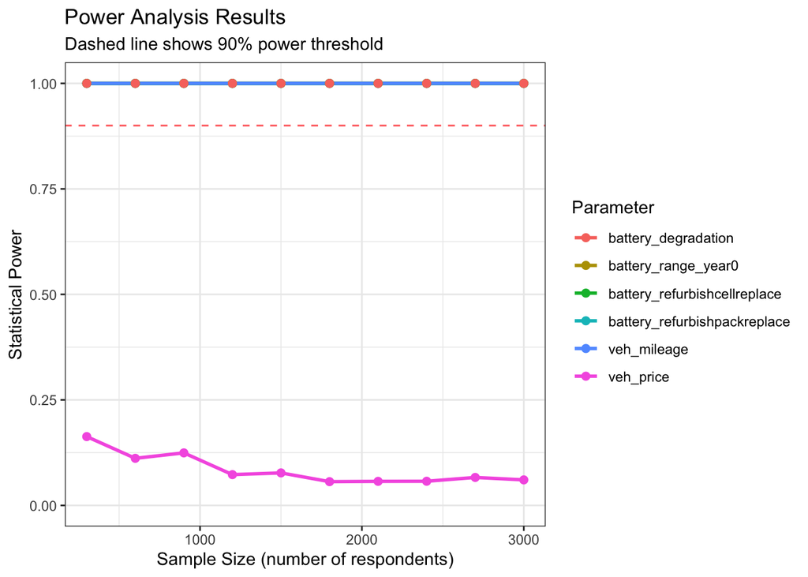

```r
plot(power_random_fixed_parameter, type = "power", power_threshold = 0.9)
```

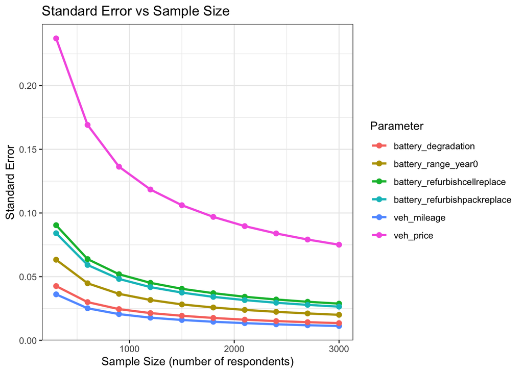

```r
plot(power_random_fixed_parameter, type = "se")
```

```r
summary(power_random_fixed_parameter, power_threshold = 0.9)
```

```
CBC Power Analysis Summary
===========================

Sample size requirements for 90% power:

veh_mileage    : n >= 300 (achieves 100.0% power, SE = 0.0361)
veh_price      : Threshold not reached (max 16.3% power at n = 3000)
battery_refurbishcellreplace: n >= 300 (achieves 100.0% power, SE = 0.0904)
battery_refurbishpackreplace: n >= 300 (achieves 100.0% power, SE = 0.0841)
battery_range_year0: n >= 300 (achieves 100.0% power, SE = 0.0633)
battery_degradation: n >= 300 (achieves 100.0% power, SE = 0.0426)
```

## random_random_parameter

```r
power_random_random_parameter <- cbc_power(
  data=choices_random_random_parameter,
  outcome = "choice",
  obsID = "obsID",
  n_q = 6,
  n_breaks = 10)
```

```
Auto-detected parameters: veh_mileage, veh_price, battery_refurbishcellreplace, battery_refurbishpackreplace, battery_range_year0, battery_degradation
```

```
Using 'respID' as panelID for panel data estimation.
```

```
Estimating models using 10 cores...
```

```
Model estimation complete!
```

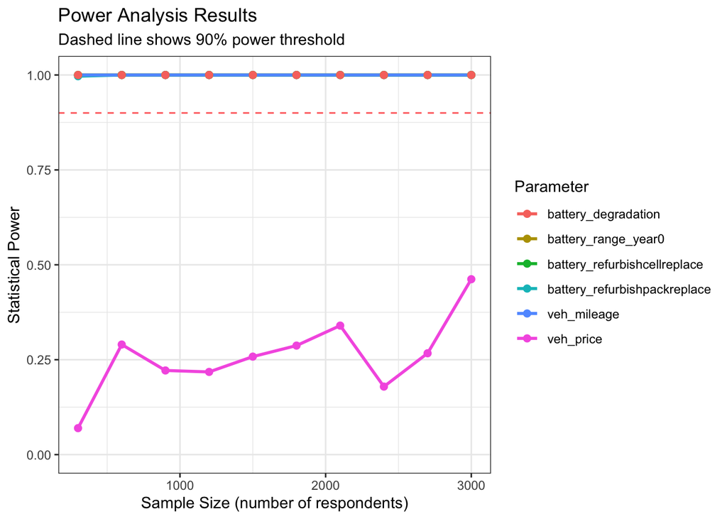

```r
plot(power_random_random_parameter, type = "power", power_threshold = 0.9)
```

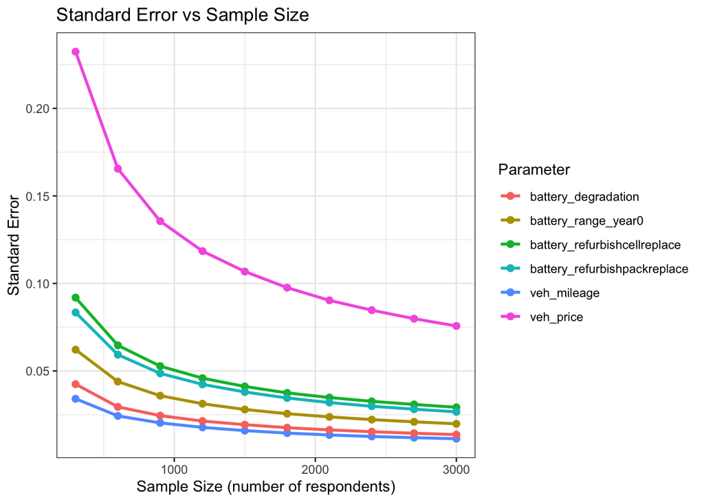

```r
plot(power_random_random_parameter, type = "se")
```

```r
summary(power_random_random_parameter, power_threshold = 0.9)
```

```
CBC Power Analysis Summary
===========================

Sample size requirements for 90% power:

veh_mileage    : n >= 300 (achieves 100.0% power, SE = 0.0341)
veh_price      : Threshold not reached (max 46.2% power at n = 3000)
battery_refurbishcellreplace: n >= 300 (achieves 100.0% power, SE = 0.0919)
battery_refurbishpackreplace: n >= 300 (achieves 99.7% power, SE = 0.0834)
battery_range_year0: n >= 300 (achieves 100.0% power, SE = 0.0622)
battery_degradation: n >= 300 (achieves 100.0% power, SE = 0.0425)
```

## shortcut

```r
power_shortcut <- cbc_power(
  data=choices_shortcut,
  outcome = "choice",
  obsID = "obsID",
  n_q = 6,
  n_breaks = 10)
```

```
Auto-detected parameters: veh_mileage, veh_price, battery_refurbishcellreplace, battery_refurbishpackreplace, battery_range_year0, battery_degradation
```

```
Using 'respID' as panelID for panel data estimation.
```

```
Estimating models using 10 cores...
```

```
Model estimation complete!
```

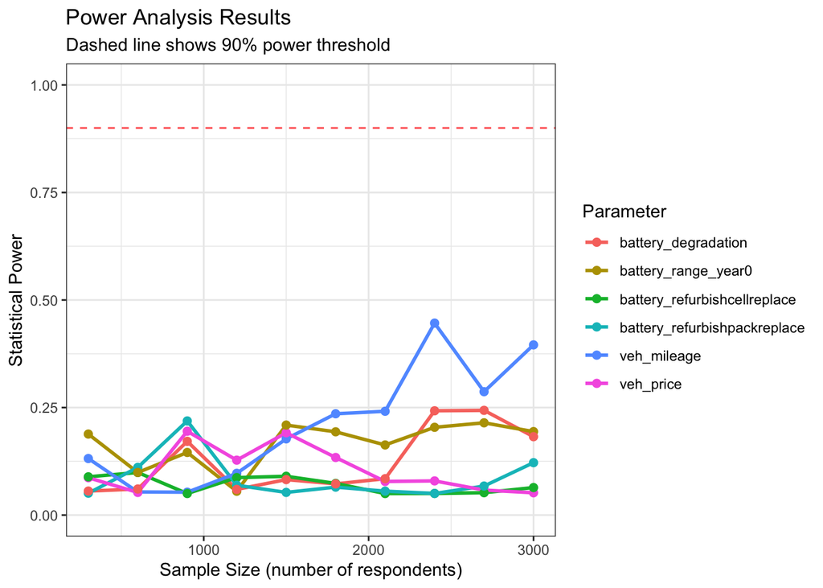

```r
plot(power_shortcut, type = "power", power_threshold = 0.9)
```

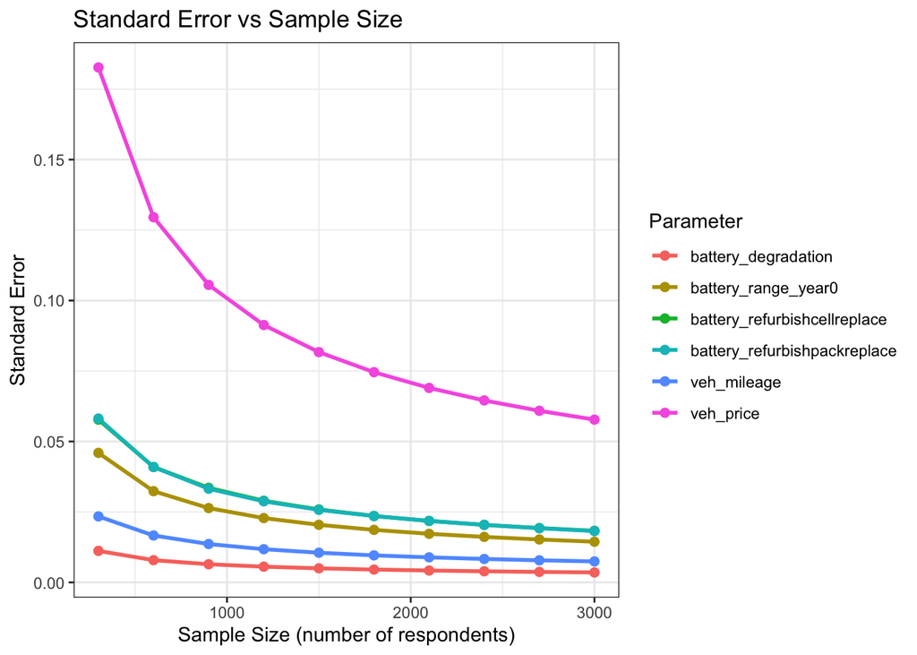

```r
plot(power_shortcut, type = "se", power_threshold = 0.9)
```

```r
summary(power_shortcut, power_threshold = 0.9)
```

```
CBC Power Analysis Summary
===========================

Sample size requirements for 90% power:

veh_mileage    : Threshold not reached (max 44.6% power at n = 3000)
veh_price      : Threshold not reached (max 19.5% power at n = 3000)
battery_refurbishcellreplace: Threshold not reached (max 9.9% power at n = 3000)
battery_refurbishpackreplace: Threshold not reached (max 21.9% power at n = 3000)
battery_range_year0: Threshold not reached (max 21.5% power at n = 3000)
battery_degradation: Threshold not reached (max 24.3% power at n = 3000)
```

## shortcut_fixed_parameter

```r
power_shortcut_fixed_parameter <- cbc_power(
  data=choices_shortcut_fixed_parameter,
  outcome = "choice",
  obsID = "obsID",
  n_q = 6,
  n_breaks = 10)
```

```
Auto-detected parameters: veh_mileage, veh_price, battery_refurbishcellreplace, battery_refurbishpackreplace, battery_range_year0, battery_degradation
```

```
Using 'respID' as panelID for panel data estimation.
```

```
Estimating models using 10 cores...
```

```
Model estimation complete!
```

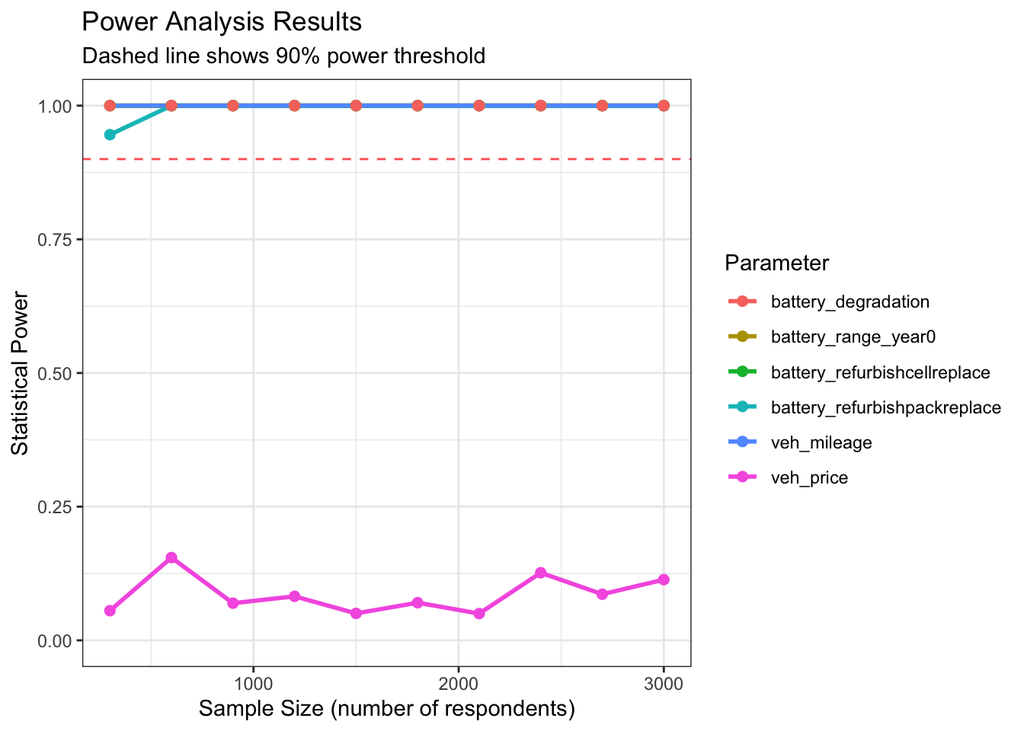

```r
plot(power_shortcut_fixed_parameter, type = "power", power_threshold = 0.9)
```

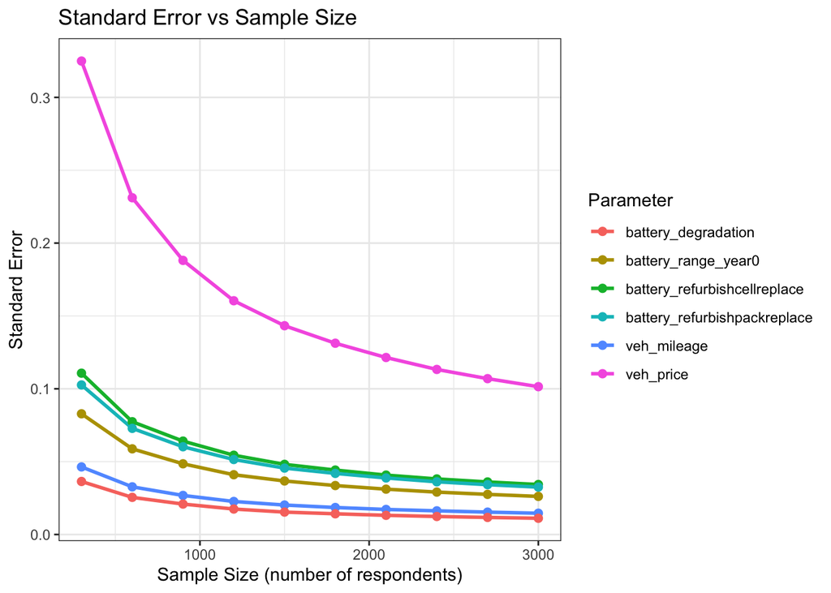

```r
plot(power_shortcut_fixed_parameter, type = "se", power_threshold = 0.9)
```

```r
summary(power_shortcut_fixed_parameter, power_threshold = 0.9)
```

```
CBC Power Analysis Summary
===========================

Sample size requirements for 90% power:

veh_mileage    : n >= 300 (achieves 100.0% power, SE = 0.0464)
veh_price      : Threshold not reached (max 15.5% power at n = 3000)
battery_refurbishcellreplace: n >= 300 (achieves 100.0% power, SE = 0.1107)
battery_refurbishpackreplace: n >= 300 (achieves 94.6% power, SE = 0.1026)
battery_range_year0: n >= 300 (achieves 100.0% power, SE = 0.0828)
battery_degradation: n >= 300 (achieves 100.0% power, SE = 0.0364)
```

## comparison

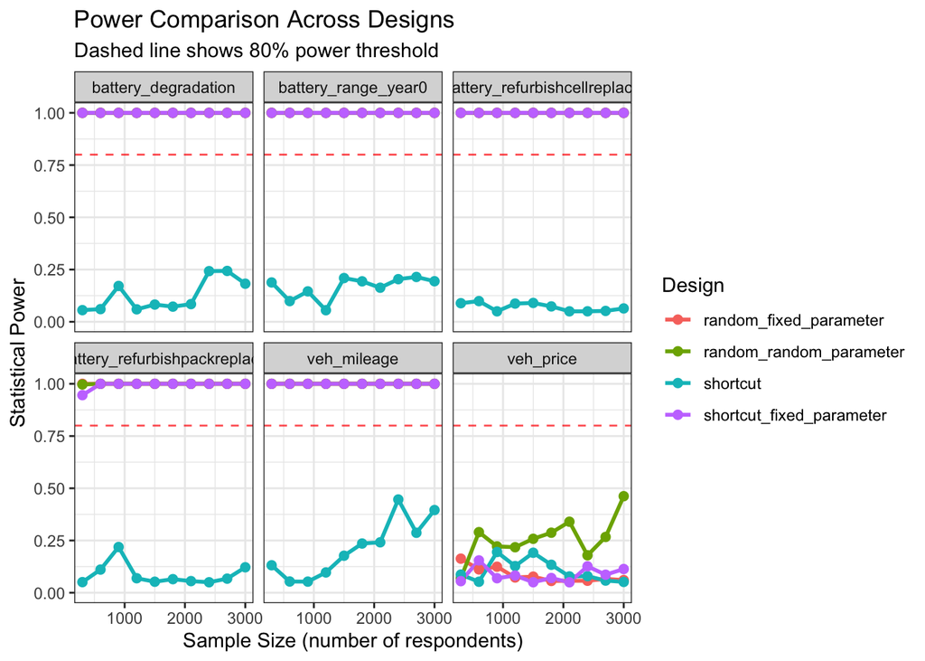

```r
plot_compare_power(
  random_fixed_parameter = power_random_fixed_parameter,
  random_random_parameter = power_random_random_parameter,
  shortcut = power_shortcut,
  shortcut_fixed_parameter = power_shortcut_fixed_parameter,
  type = "power"
)
```

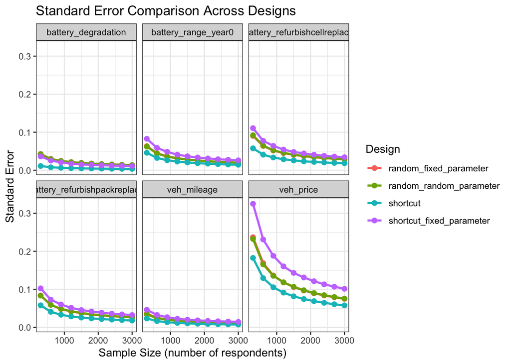

```r
plot_compare_power(
  random_fixed_parameter = power_random_fixed_parameter,
  random_random_parameter = power_random_random_parameter,
  shortcut = power_shortcut,
  shortcut_fixed_parameter = power_shortcut_fixed_parameter,
  type = "se"
)
```